# Notebook 08

## Getting Started

Before running this notebook, select “Session > Restart R and Clear Output” in the menu above to start a new R session. You may also have to hit the broom in the upper right-hand corner of the window. This will clear any old data sets and give us a blank slate to start with.

After starting a new session, run the following code chunk to load the libraries and data that we will be working with today.

I have set the options `message=FALSE` and `echo=FALSE` to avoid cluttering your solutions with all the output from this code.

## Reading the Data

Today we are going to look at a subset of a well-known text analysis corpus call NewsGroups-20. It’s an old set of mailing list archives from 20 different categories.

```r
docs <- read_csv("../data/newsgroups.csv.bz2")
anno <- read_csv("../data/newsgroups_token.csv.bz2")
```

## Questions

### Supervised Learning

Build an elastic net model to determine the category of the newsgroup messages:

```r
model <- dsst_enet_build(anno, docs)
```

```
## Training
##
## Fold: 1/3
##
## Fold: 2/3
##
## Fold: 3/3
##
```

Produce a confusion matrix for the messages. Take note of any commonly confused categories:

```r
dsst_confusion_matrix(model)
```

```
##
##                            alt.atheism comp.graphics
##   alt.atheism                       15             0
##   comp.graphics                      0             7
##   comp.os.ms-windows.misc            0             0
##   comp.sys.ibm.pc.hardware           0             2
##   comp.sys.mac.hardware              2             5
##   comp.windows.x                     0             1
##   misc.forsale                       0             2
##   rec.autos                          0             0
##   rec.motorcycles                    0             0
##   rec.sport.baseball                 1             0
##   rec.sport.hockey                   0             0
##   sci.crypt                          0             1
##   sci.electronics                    0             1
##   sci.med                            2             1
##   sci.space                          0             0
##   soc.religion.christian             1             0
##   talk.politics.guns                 1             0
##   talk.politics.mideast              1             0
##   talk.politics.misc                 0             1
##   talk.religion.misc                 7             1
##
##                            comp.os.ms-windows.misc comp.sys.ibm.pc.hardware
##   alt.atheism                                    0                        0
##   comp.graphics                                  6                        0
##   comp.os.ms-windows.misc                       18                        1
##   comp.sys.ibm.pc.hardware                       5                       12
##   comp.sys.mac.hardware                          0                        2
##   comp.windows.x                                 4                        1
##   misc.forsale                                   2                        2
##   rec.autos                                      0                        0
##   rec.motorcycles                                0                        0
##   rec.sport.baseball                             0                        0
##   rec.sport.hockey                               0                        0
##   sci.crypt                                      0                        2
##   sci.electronics                                1                        2
##   sci.med                                        1                        0
##   sci.space                                      1                        0
##   soc.religion.christian                         0                        0
```

[output cut: 143 more lines]

```
##   comp.windows.x                           15
##   misc.forsale                             12
##   rec.autos                                14
##   rec.motorcycles                          10
##   rec.sport.baseball                       19
##   rec.sport.hockey                         16
##   sci.crypt                                13
##   sci.electronics                          22
##   sci.med                                  19
##   sci.space                                16
##   soc.religion.christian                   11
##   talk.politics.guns                       22
##   talk.politics.mideast                    16
##   talk.politics.misc                       21
##   talk.religion.misc                       25
```

Look at the positive coefficients from the model; perhaps use `lambda_num = 30`. Do the terms seem to correspond to the categories in an expected way?

```r
dsst_coef_positive(model, lambda_num = 30)
```

```
##              alt.atheism : atheist; jon; Koran; benedikt
##            comp.graphics : graphic; computer
##  comp.os.ms-windows.misc : Windows; Ultra; 3.1
## comp.sys.ibm.pc.hardware : IDE; floppy; Lang; clone; bus
##    comp.sys.mac.hardware : Mac; tech; PDS; upgrade; Apple; mac
##           comp.windows.x : window; X11R5; text
##             misc.forsale : sale; shipping; interested; condition; obo
##                rec.autos : car
##          rec.motorcycles : dod; ride; bike; DoD; Stafford; Winona; BMW; disclaimer
##       rec.sport.baseball : pitcher; baseball; Baseball; Morris; batting; bat; Mets; batter
##         rec.sport.hockey : playoff; hockey; game; Vancouver; play; Penguins; goalie; Potvin; Rangers
##                sci.crypt : encryption; key; Sternlight; Clipper; NSA
##          sci.electronics : circuit; resistor; differential; ohm
##                  sci.med : medical; therapy; medicine; Medicine; symptom; food; prescribe; additive
##                sci.space : orbit; space; pat; 91109; 3684; 525; aweto; caterpillar; Telos; Lunar; km; NASA
##   soc.religion.christian : Christ; Bible; church; Christians; scripture; faith; Church; Christianity; marriage
##       talk.politics.guns : firearm; weapon; gun; cult; shooting
##    talk.politics.mideast : Israel; israeli; turkish; occupy; soviet; Serdar; Argic; Hamid; Barlow; Shostack; extermination; Jews; Cyprus; Turks; Armenians
##       talk.politics.misc : Clayton; libertarian; situation
##       talk.religion.misc : thrilling; BD
```

Now, use the G-score metrics to find the terms that are most associated with each category. Again, do these seem to match your intuition?

```r
dsst_metrics(anno, docs)
```

```
## [[1]]
## # A tibble: 1,714 × 7
##    label       token         count expected count_word gscore  chi2
##    <chr>       <chr>         <int>    <dbl>      <int>  <dbl> <dbl>
##  1 alt.atheism "_"              22  118.          2612  123.   82.7
##  2 alt.atheism "\""            192   91.7         2032   89.7 116.
##  3 alt.atheism "coin"           14    0.722         16   74.9 256.
##  4 alt.atheism "atheism"        14    0.767         17   71.2 239.
##  5 alt.atheism "observation"    12    0.586         13   67.4 233.
##  6 alt.atheism "probability"    12    0.767         17   54.2 172.
##  7 alt.atheism "atheist"        11    0.677         15   51.2 165.
##  8 alt.atheism "hypothesis"     10    0.812         18   38.0 109.
##  9 alt.atheism "appearance"      8    0.586         13   32.7  98.2
## 10 alt.atheism "head"           12    1.58          35   31.5  72.1
## # … with 1,704 more rows
##
## [[2]]
## # A tibble: 2,994 × 7
##    label         token     count expected count_word gscore  chi2
##    <chr>         <chr>     <int>    <dbl>      <int>  <dbl> <dbl>
##  1 comp.graphics image        60     5.74         85  224.   550.
##  2 comp.graphics datum        61     8.45        125  165.   351.
##  3 comp.graphics -           280   132.         1957  139.   179.
##  4 comp.graphics package      44     6.02         89  120.   257.
##  5 comp.graphics ftp          28     2.57         38  109.   270.
##  6 comp.graphics graphic      27     2.50         37  104.   257.
##  7 comp.graphics available    43     6.76        100  103.   209.
##  8 comp.graphics format       32     3.92         58   96.4  216.
##  9 comp.graphics SGI          19     1.35         20   94.6  247.
## 10 comp.graphics Graphics     17     1.49         22   68.7  174.
## # … with 2,984 more rows
##
## [[3]]
## # A tibble: 1,323 × 7
##    label                   token   count expected count_word gscore  chi2
##    <chr>                   <chr>   <int>    <dbl>      <int>  <dbl> <dbl>
##  1 comp.os.ms-windows.misc Windows    30    1.15          42  166.  743.
##  2 comp.os.ms-windows.misc I         220   87.3         3183  150.  211.
##  3 comp.os.ms-windows.misc M          12    0.521         19   61.7 260.
##  4 comp.os.ms-windows.misc file       25    3.98         145   53.2 114.
```

[output cut: 264 more lines]

```
## [[20]]
## # A tibble: 2,031 × 7
##    label              token   count expected count_word gscore  chi2
##    <chr>              <chr>   <int>    <dbl>      <int>  <dbl> <dbl>
##  1 talk.religion.misc _          15  137.          2612  185.  116.
##  2 talk.religion.misc Jim        27    2.15          41  108.  304.
##  3 talk.religion.misc of        351  221.          4217   70.9  82.6
##  4 talk.religion.misc context    16    1.26          24   64.7 182.
##  5 talk.religion.misc Weiss       9    0.524         10   46.7 145.
##  6 talk.religion.misc x           2   26.6          508   40.2  24.1
##  7 talk.religion.misc FBI        15    1.99          38   40.0  89.7
##  8 talk.religion.misc fire       17    2.72          52   38.3  79.0
##  9 talk.religion.misc -          48  103.          1957   38.1  30.9
## 10 talk.religion.misc article    17    2.83          54   37.0  74.9
## # … with 2,021 more rows
```

### Unsupervised Learning

Let’s move on to new material. Compute the first two principal components of the categories. Remember to set the document variable to “label”.

```r
dsst_pca(anno, docs, doc_var = "label")
```

```
## # A tibble: 20 × 3
##    label                         v1      v2
##    <chr>                      <dbl>   <dbl>
##  1 alt.atheism               0.254   0.293
##  2 comp.graphics            -0.252   0.188
##  3 comp.os.ms-windows.misc  -0.330   0.286
##  4 comp.sys.ibm.pc.hardware -0.369   0.265
##  5 comp.sys.mac.hardware    -0.321   0.216
##  6 comp.windows.x           -0.257   0.248
##  7 misc.forsale             -0.258   0.0577
##  8 rec.autos                -0.0191 -0.118
##  9 rec.motorcycles          -0.0150 -0.132
## 10 rec.sport.baseball        0.0372 -0.337
## 11 rec.sport.hockey          0.0419 -0.329
## 12 sci.crypt                 0.0249  0.0980
## 13 sci.electronics          -0.146   0.0430
## 14 sci.med                   0.0552 -0.0248
## 15 sci.space                -0.0200 -0.0580
## 16 soc.religion.christian    0.310   0.359
## 17 talk.politics.guns        0.225   0.163
## 18 talk.politics.mideast     0.177   0.0805
## 19 talk.politics.misc        0.244   0.138
## 20 talk.religion.misc        0.353   0.407
```

Plot (in R) the first two principal components of the categories. Try to find some of the document pairs in the PCA plot.

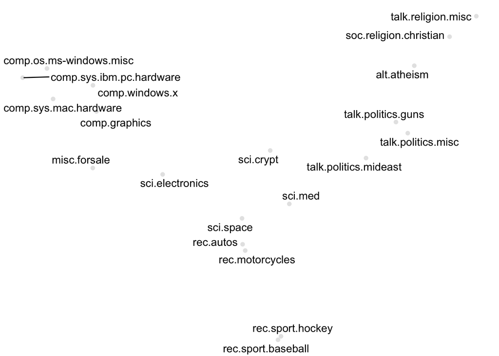

```r
dsst_pca(anno, docs, doc_var = "label") %>% dsst_plot_dred()
```

Now, produce a corresponding UMAP plot. Is this easier or more difficult to interpret?

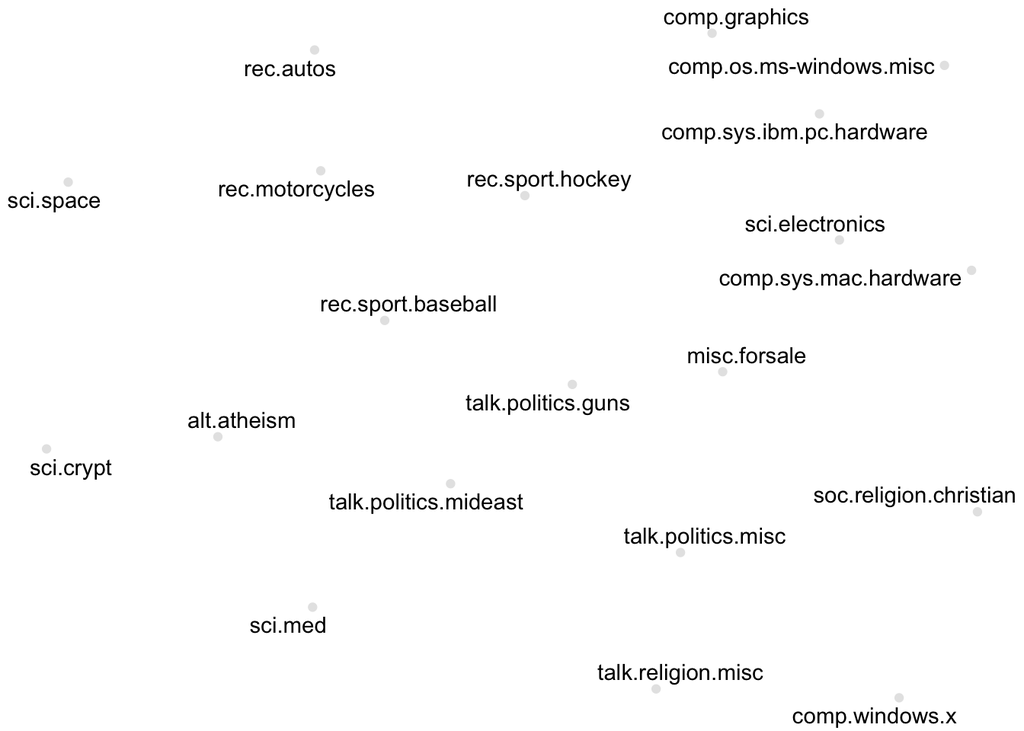

```r
dsst_umap(anno, docs, doc_var = "label") %>% dsst_plot_dred()
```

Next, produce the principal components for the messages themselves. Save the results as a JSON file and go to the link below to visualise the results. Color the points based on the labels.

- https://statsmaths.github.io/text-embed-explo/build/

```r
dsst_pca(anno) %>% dsst_json_drep(docs, color_var = "label")
```

Repeat the last question for the UMAP parameters. Did you find any interesting clusters of documents?

```r
dsst_umap(anno) %>% dsst_json_drep(docs, color_var = "label")
```

Make sure to not rush through this step; take a couple minutes to pan around in the embedding space.